# HW 4

Britt Bovbjerg

2/12/2020

1. Get a frequency breakdown of the number of chicks, their average weight and the standard deviation of the weights in each of the diets at the start of the study. Store the resulting data frame in a variable named `weight0` and print.

```r
library(dplyr)
```

```r
library(ggplot2)
dat1 <- ChickWeight %>%
  filter(Time == 0) %>%
  group_by(Diet)

weight0 <- summarize(dat1,
                     average_weight = mean(weight, na.rm = TRUE),
                     sd_weight = sd(weight, na.rm = TRUE))

weight0
```

| Diet | average_weight | sd_weight |
| --- | --- | --- |
| 1 | 41.4 | 0.9947229 |
| 2 | 40.7 | 1.4944341 |
| 3 | 40.8 | 1.0327956 |
| 4 | 41.0 | 1.0540926 |

2. Each chick should have twelve weight measurements. Use the `dplyr` package to identify how many measurements are there for each chick. Extract a subset of the data for all chicks with complete information, name the data set `complete`, and print the first 3 rows. (Hint: you might want to use mutate to introduce a helper variable consisting of the number of observations)

```r
complete <- ChickWeight %>%
  group_by(Chick) %>%
  mutate(total=n()) %>%
  filter(total == 12)

head(complete, 3)
```

| weight | Time | Chick | Diet | total |
| --- | --- | --- | --- | --- |
| 42 | 0 | 1 | 1 | 12 |
| 51 | 2 | 1 | 1 | 12 |
| 59 | 4 | 1 | 1 | 12 |

4. In the complete data set introduce a new variable that measures the current weight difference compared to day 0. Name this variable `weightgain` and print the first 3 rows of the new data frame.

```r
dat4 <- ChickWeight %>%
  group_by(Chick) %>%
  mutate(weightgain = weight - weight[Time == 0])

head(dat4, 3)
```

| weight | Time | Chick | Diet | weightgain |
| --- | --- | --- | --- | --- |
| 42 | 0 | 1 | 1 | 0 |
| 51 | 2 | 1 | 1 | 9 |
| 59 | 4 | 1 | 1 | 17 |

5. Use `{ggplot2}` to create side-by-side boxplots of `weightgain` by `Diet` for day 21. Change the order of the categories in the Diet variable such that the boxplots are ordered by median `weightgain`, and the lower limit of the y axis should be 0. Describe the relationship in 2-3 sentences.

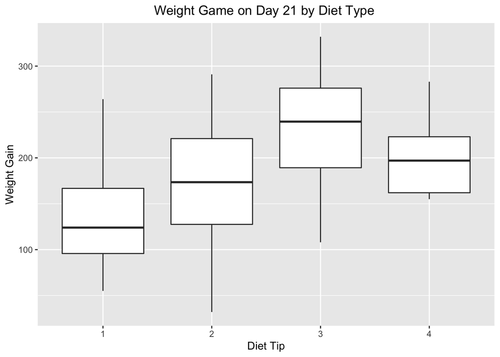

```r
dat5 <- dat4 %>%
  filter(Time== 21)

ggplot(dat5, aes(x= Diet, y=weightgain)) +
  geom_boxplot() +
  labs(title="Weight Game on Day 21 by Diet Type ",
       x = "Diet Tip",
       y = "Weight Gain") +
  theme(plot.title = element_text(hjust = 0.5))
```

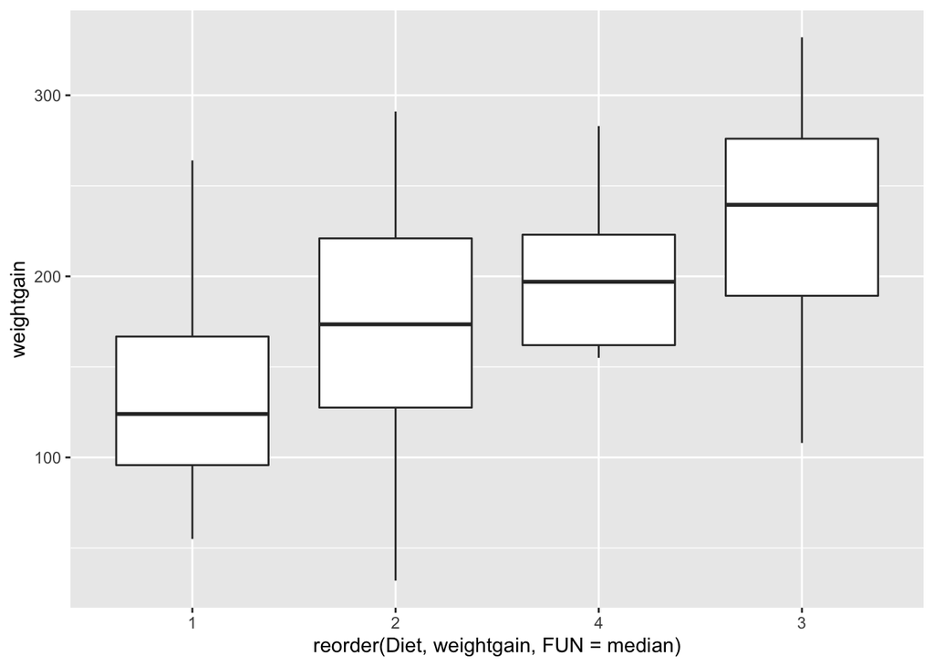

```r
ggplot(dat5, aes(x = reorder(Diet, weightgain, FUN=median), y = weightgain)) +
  geom_boxplot()
```

From the graph it looks like chicks on diet 1 gained the least weight, and chicks on diet 3 gained the most, followed by chicks on diet 4 then on diet 2.

6. Answer each of the following questions using numerical and graphical summary. Also explain what you found:
1. Which chick gained the most weight and which gained the least weight?

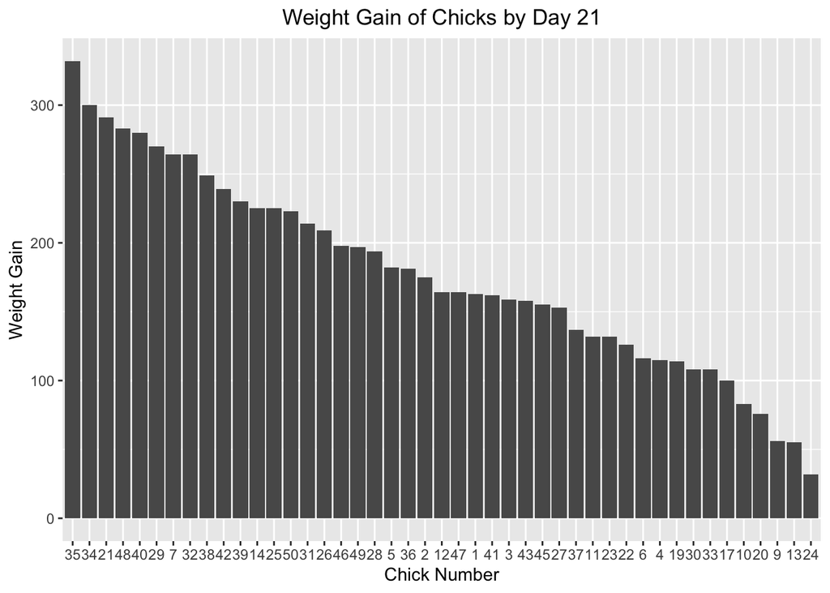

```r
ggplot(dat5, aes(x=reorder(Chick, -weightgain), weight=weightgain)) + geom_bar() +
  labs(title="Weight Gain of Chicks by Day 21",
       x = "Chick Number",
       y = "Weight Gain") +
  theme(plot.title = element_text(hjust = 0.5))
```

```r
dat5 %>% ungroup %>%
  summarize(max = max(weightgain),
            maxChick = Chick[which(weightgain == max(weightgain))],
            min = min(weightgain),
            minChick = Chick[which(weightgain == min(weightgain))])
```

| max | maxChick | min | minChick |
| --- | --- | --- | --- |
| 332 | 35 | 32 | 24 |

Chick 35 gained the most weight (332gm) by day 21, and chick 24 gained the least weight (32gm).

2. What diets were they on?

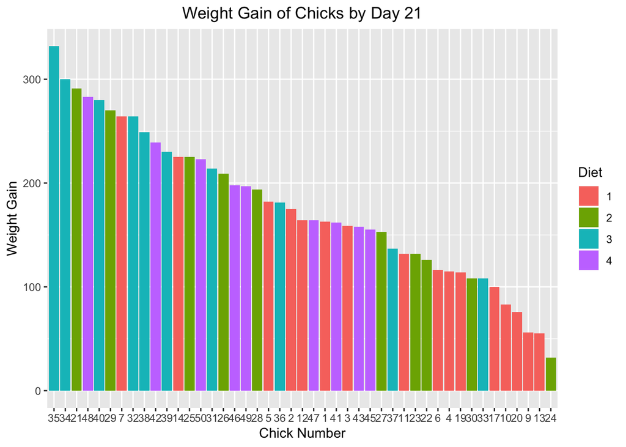

```r
ggplot(dat5, aes(x=reorder(Chick, -weightgain), weight=weightgain, fill=Diet)) + geom_bar() +
  labs(title="Weight Gain of Chicks by Day 21",
       x = "Chick Number",
       y = "Weight Gain") +
  theme(plot.title = element_text(hjust = 0.5))
```

```r
dat5 %>% ungroup %>%
  summarize(max = max(weightgain),
            maxChick = Chick[which(weightgain == max(weightgain))],
            maxChickDiet = Diet[which(weightgain == max(weightgain))],
            min = min(weightgain), minChick = Chick[which(weightgain                ==min(weightgain))],
            minChickDiet = Diet[which(weightgain == min(weightgain))])
```

| max | maxChick | maxChickDiet | min | minChick | minChickDiet |
| --- | --- | --- | --- | --- | --- |
| 332 | 35 | 3 | 32 | 24 | 2 |

The chick that gained the most weight was on diet 3, and the chick that gained the least weight was on diet 2.

7. For the chicks with the least and the most weight at time 0, plot their growth trajectories over time.

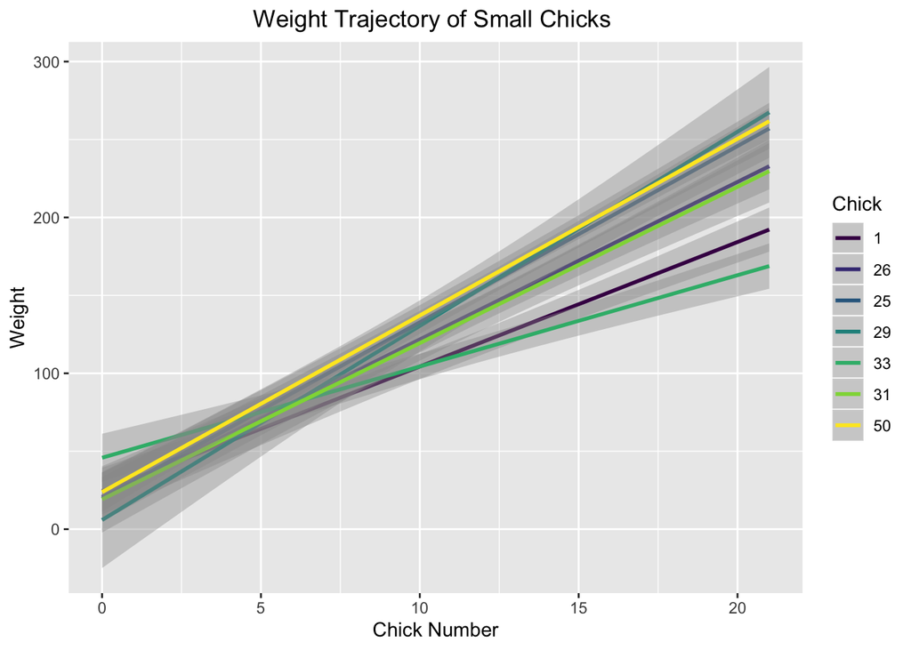

```r
min_max <- dat4 %>% ungroup %>%
  filter(Time == 0) %>%
  filter(weight== max(weight) | weight==min(weight))

lilChicks <- min_max %>%
  filter(weight == 39) %>%
  select(Chick)

lil <- as.numeric(lilChicks$Chick)


bigChicks <- min_max %>%
  filter(weight == 43) %>%
  select(Chick)

big <- as.numeric(bigChicks$Chick)

dat4 %>%
  filter(Chick %in% lil) %>%
  ggplot(aes(x=Time, y=weight, color=Chick)) + geom_smooth(method="lm")+ labs(title="Weight Trajectory of Small Chicks ",
       x = "Chick Number",
       y = "Weight") +
  theme(plot.title = element_text(hjust = 0.5))
```

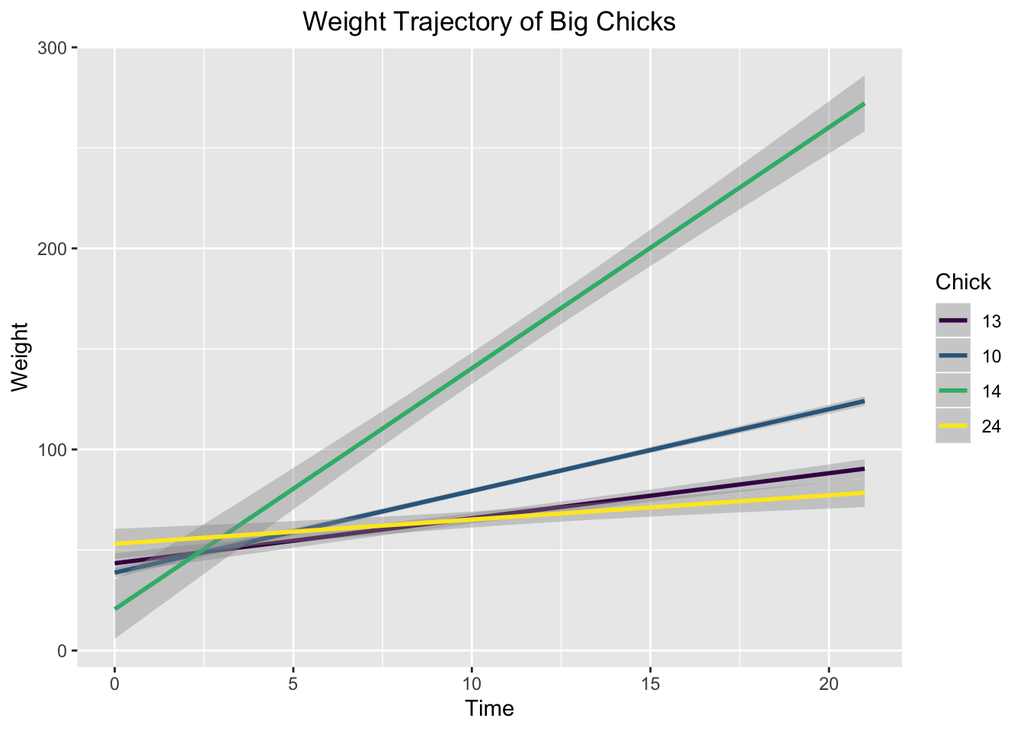

```r
dat4 %>%
  filter(Chick %in% big) %>%
  ggplot(aes(x=Time, y=weight, color=Chick)) + geom_smooth(method="lm")+ labs(title="Weight Trajectory of Big Chicks",
       x = "Time",
       y = "Weight") +
  theme(plot.title = element_text(hjust = 0.5))
```

8. Add to the previous plot the average growth trajectory for all chicks (calculated as the mean weight for each chick at each time). How do the trajectories compare?

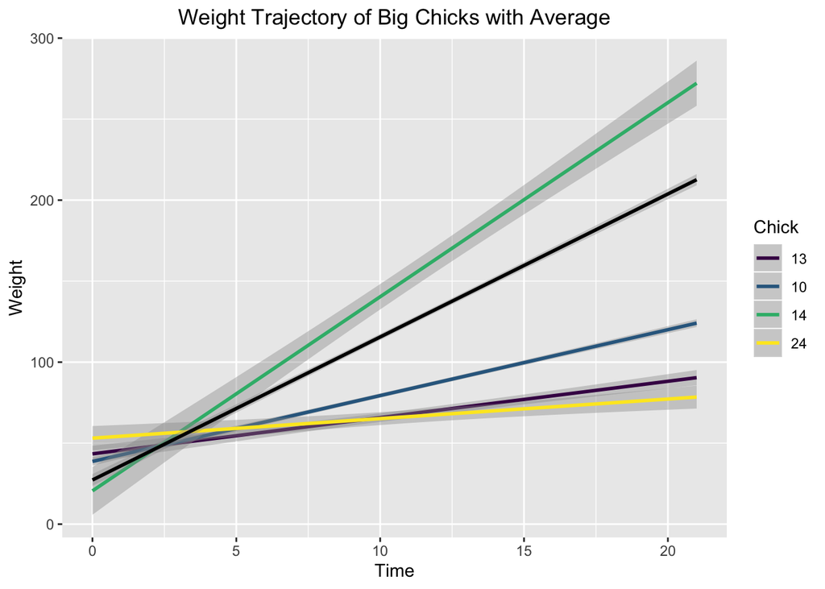

```r
dat8 <- dat4 %>% ungroup %>%
  group_by(Time) %>%
  mutate(averageWeight = mean(weight))

dat8big <- dat8 %>%
  filter(Chick %in% big)

ggplot() +
  geom_smooth(data=dat8big, aes(x=Time, y=weight,color=Chick), method ="lm") +
  geom_smooth(data=dat8big, aes(x=Time, y=averageWeight), method ="lm", color="Black")+
  labs(title="Weight Trajectory of Big Chicks with Average",
       x = "Time",
       y = "Weight") +
  theme(plot.title = element_text(hjust = 0.5))
```

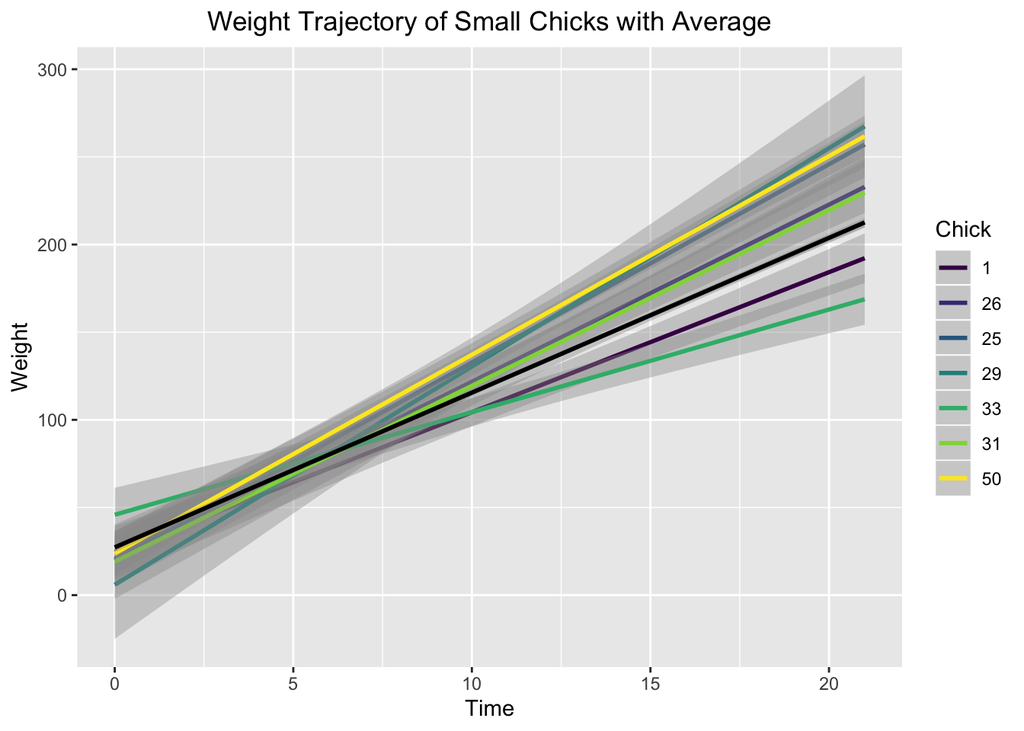

```r
dat8lil <- dat8 %>%
  filter(Chick %in% lil)

ggplot() +
  geom_smooth(data=dat8lil, aes(x=Time, y=weight,color=Chick), method ="lm") +
  geom_smooth(data=dat8lil, aes(x=Time, y=averageWeight), method ="lm", color="Black")+
  labs(title="Weight Trajectory of Small Chicks with Average",
       x = "Time",
       y = "Weight") +
  theme(plot.title = element_text(hjust = 0.5))
```

9. What else do you find interesting in the dataset? Show your exploratory analysis.

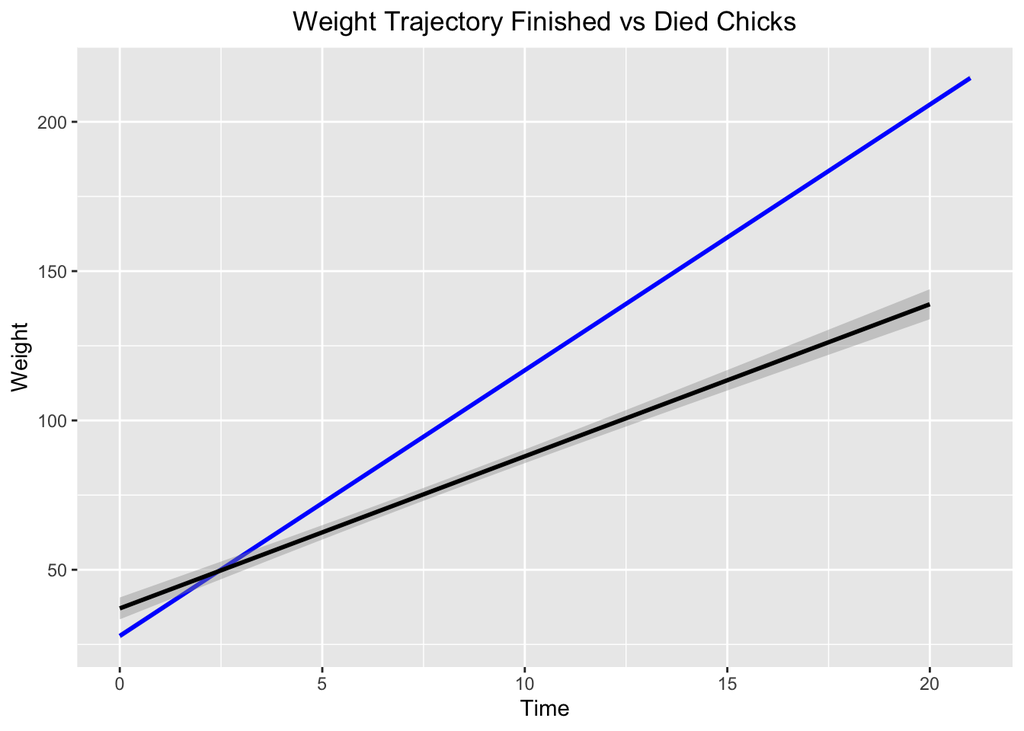

```r
dat9finished <- ChickWeight %>%
  group_by(Chick) %>%
  mutate(finished=n()) %>%
  mutate(finished = ifelse(finished== 12, "Finished", "Died" )) %>%
  filter(finished == "Finished") %>%
  group_by(Time) %>%
  mutate(averageWeight = mean(weight))

dat9died <- ChickWeight %>%
  group_by(Chick) %>%
  mutate(finished=n()) %>%
  mutate(finished = ifelse(finished== 12, "Finished", "Died" )) %>%
  filter(finished == "Died") %>%
  group_by(Time) %>%
  mutate(averageWeight = mean(weight))

ggplot() +
  geom_smooth(data=dat9finished, aes(x=Time, y=averageWeight), method ="lm", color = "blue") +
  geom_smooth(data=dat9died, aes(x=Time, y=averageWeight), method ="lm", color = "black")+
  labs(title="Weight Trajectory Finished vs Died Chicks",
       x = "Time",
       y = "Weight") +
  theme(plot.title = element_text(hjust = 0.5))
```

I wondered if the chicks that didn’t finish the expierement (those who didn’t have 12 total weigh ins) differed from those that did. I assumed that because they didn’t finish they may have died in development, so I hypothesized that they would have lower weight gain than those who finished the experiment.

From my graph it looks like on average chicks that died grew slower than chicks that survived.